# How FDA can vet dose-escalation trials for safety

David C. Norris

9/20/2020

# Background

Norris (2020) examines a fatal dose-finding trial ([AFM11-102](https://clinicaltrials.gov/ct2/show/NCT02848911)) in retrospect, through the lens of a somewhat realistic Bayesian model of ordinal toxicity outcomes. When this model is estimated *using only data from the first 5 dose cohorts*, it foresees as reasonably likely the fatal toxicity which actually occurred in the 6th cohort. Thus, even in this inherently unsafe trial, disaster might still have been averted through the dynamic ‘situational awareness’ a realistic model can deliver.

Unfortunately, realistic models of the kind employed in Norris (2020) are unlikely to be contemplated or even understood by trial sponsors who deploy 3+3 designs like the one in question. Indeed, even FDA’s Oncology Center of Excellence (OCE) expresses at best [limited enthusiasm](https://precisionmethods.guru/2020/04/21/fda-oce-response-on-dose-individualization/) for early-phase trial designs that are cognizant of inter-individual heterogeneity. Thus, the question arises: would a less sophisticated analysis have enabled the sponsor, or FDA, to recognize this trial’s unsafe design from the outset?

# Mapping the trial to the `precautionary` package

AFM11-102 used two modifications that do not map readily to designs implemented in the `escalation` package on which `precautionary` is based. Firstly, whereas the design specified an initial ‘accelerated titration’ phase (Simon et al. 1997), we will simply simulate a standard ‘3+3’ design. Secondly, the trial employed step-up dosing such that patients initiated treatment at 1/3 of their cohort’s target dose, stepping up to the full dose after 1 week. Whereas the abovementioned Bayesian model exploited the extra information available from this step-up protocol, we will for present purposes regard each cohort as characterized simply by its target dose:

Note that omitting the accelerated titration makes our simulated trial safer, thus biasing our analysis toward a finding of safety.

```r
library(precautionary)
design <- get_three_plus_three(num_doses = 6)
options(dose_levels = c(2, 6, 20, 60, 180, 400)) # ng/kg/week
```

As in Norris (2020), we suppose $\mathrm{MTD}_i$ is lognormally distributed, with a coefficient of variation (CV) of 1/2, and a median centered at the next-to-highest dose of 180 ng/kg/week. We allow for a ±60% uncertainty in this median.

That is, $\log(median) \sim \mathscr{N}(\log 180, 0.6)$.

Figure 1: Multiple samples from a *hyperprior* over the distribution of MTD$_i$.

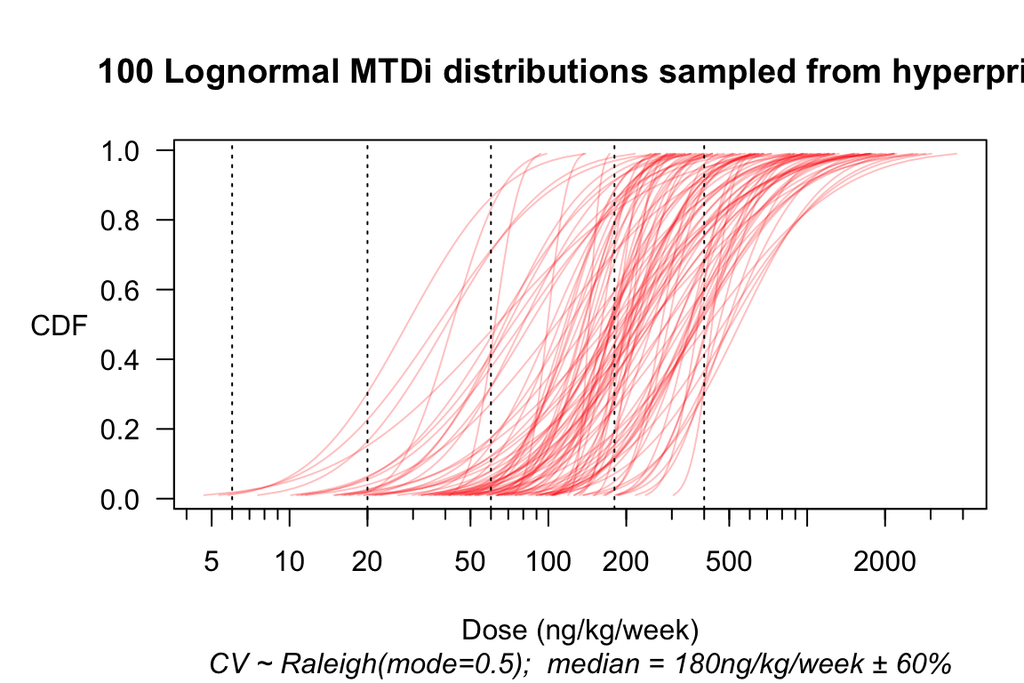

```r
mtdi_gen <- hyper_mtdi_lognormal(CV = 0.5
                                ,median_mtd = 180
                                ,median_sdlog = 0.6
                                ,units="ng/kg/week"
                                )
plot(mtdi_gen, n=100, col=adjustcolor("red", alpha=0.25))
```

Finally, we introduce a standard ‘ordinalizer’ that assumes the toxicity-grade thresholds for any individual patient are a geometric sequence of doses with ratio $r_0$.

With our focus being *safety*, it is important mainly that these dose ratios hold between the *higher* grades, linking Grades 3–4, and Grades 4–5.

```r
options(ordinalizer = function(MTDi, r0 = 1.5) {
  MTDi * r0 ^ c(Gr1=-2, Gr2=-1, Gr3=0, Gr4=1, Gr5=2)
})
```